# Long Term S&P 500 Models

Micah Williams

3/18/2021

```
##   id       date    factor pct_change
## 1  1 1871-01-01 0.9835855 -1.6414548
## 2  2 1871-02-01 1.0094895  0.9489529
## 3  3 1871-03-01 1.0666667  6.6666667
## 4  4 1871-04-01 1.0495340  4.9534036
## 5  5 1871-05-01 1.0073352  0.7335199
## 6  6 1871-06-01 0.9813165 -1.8683530
```

This dataset contains monthly inflation-adjusted (in January 2021 dollars) average closing prices of the S&P 500 index. There are **1,803** rows in the dataset, and each row contains a date, the first day of a month, and a value, the average closing price of the index during the month ending on the given day. The dates range from Jan. 1, 1871 to March 1, 2021. The average closing prices range from $70.77 to $3901.82.

Here’s what the data looks like with the y-axis on a log scale, with recessions marked with shaded areas:

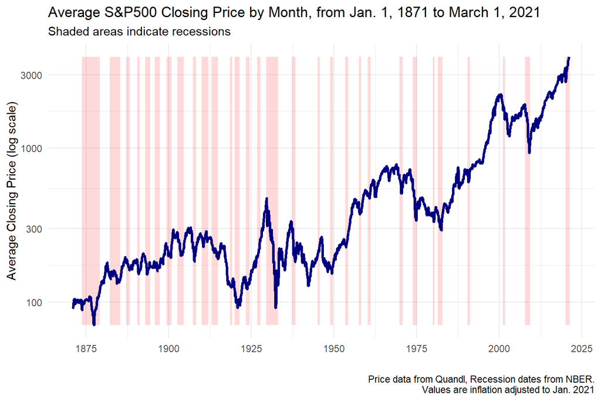

## Time in the Market

```
## [1] 418605.3
```

```
## [1] 551338.1
```

Now, let’s pretend you have $10,000 to invest. If you invested it all on Jan. 1 1871, you’d have around $419,000 today. A handsome return! It’s a shame you’re too dead to enjoy it.

If you had waited for the market to crash, as it did a few years later, and bought in when the S&P was at its lowest (down around 25% from Jan. 1871), you’d have more than $551,000. You’d be the richest dead guy in the cemetary!

Of course, you probably want to enjoy your wealth while you’re still alive, and 150 years is a long time to wait. If you only had 40 years to invest, what month would’ve been the best to start?

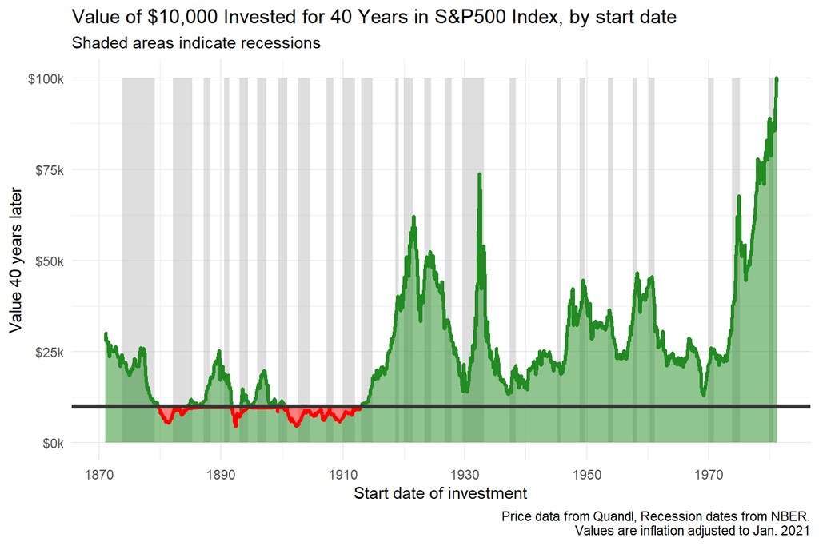

Most of the local peaks occur in months where recessions end and prices are bottoming out.

## Timing the Market

Now, you might look at the graph above and think, “Well, why don’t I just wait for the market to crash, and I’ll buy when things are cheaper!” You certainly wouldn’t be alone in that logic. Let’s say you keep the 40 year investment interval, but instead of investing everything at the beginning, you wait and try to buy when you think the prices are at their lowest.

With the simple math above, it wouldn’t make much of a difference- the only penalty for waiting to invest is rising prices. But, in the real world, how long you keep an investment matters much more because some stocks pay dividends, which can be reinvested. In this way, investors can use compound interest to grow the value of their investment exponentially. In reality, the value of dividends changes just like the stock, but to simplify things, let’s assume an annual 2% dividend, and that we’ll immediately reinvest the dividend. For example, if you invest $10,000, and the index increases 10%, at the end of the first year you’ll have $11,220: $10,000 principal, $1,000 (10%) appreciation, and a 2% ($220) dividend on your new principal of $11,000.

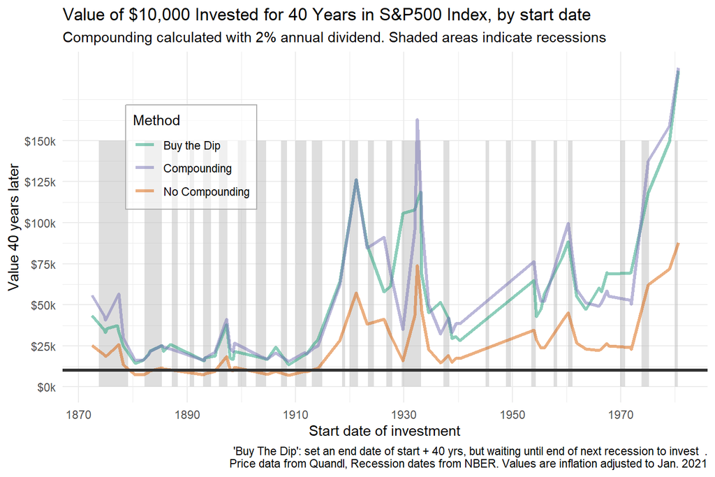